# Sentiment Analysis Badge

LASER Institute TM Learning Lab 2

Katie McCarthy

July 14, 2022

[figure not shown]

The final activity for each learning lab provides space to work with data and to reflect on how the concepts and techniques introduced in each lab might apply to your own research.

To earn a badge for each lab, you are required to respond to a set of prompts for two parts:

- In Part I, you will reflect on your understanding of key concepts and begin to think about potential next steps for your own study.
- In Part II, you will create a simple data product in R that demonstrates your ability to apply a data analysis technique introduced in this learning lab.

### Part I: Reflect and Plan

Use the institutional library (e.g. [NCSU Library](https://www.lib.ncsu.edu/#articles)), [Google Scholar](https://scholar.google.com/) or search engine to locate a research article, presentation, or resource that applies text mining to an educational context or topic of interest. More specifically, **locate a text mining study that visualize text data.**

1. Provide an APA citation for your selected study.
   - Boon-Itt, S., & Skunkan, Y. (2020). Public perception of the COVID-19 pandemic on Twitter: sentiment analysis and topic modeling study. *JMIR Public Health and Surveillance*, *6*(4), e21978.
2. How does the sentiment analysis address research questions?
   - Not an education-specific question, but of larger social interest. This study looks at Twitter chatter about COVID-19 from Dec 2019- Mar 2020 to better understand and respond to large-scale social issues.
   - In addition to word clouds, the authors use sentiment analysis (Figures 7 and 8) to do a “temperature check” of the world in the early stages of the pandemic. It is interesting (and perhaps, retrospectively unsurprising) that two most prominent sentiments were “fear” and “anticipation”.

Draft a research question for a population you may be interested in studying, or that would be of interest to educational researchers, and that would require the collection of text data and answer the following questions:

1. What text data would need to be collected?
   - We are interested in examining how students navigate across multiple, conflicting texts related to emotion and belief-laden socio-scientific issues (e.g., should there be universal basic income, should we require vaccinations, is climate change man-made). To understand how students’ affect (either task or topic related), we could collect think-alouds or retrospective interviews about how they navigated and thought about the texts.
2. For what reason would text data need to be collected in order to address this question?
   - Though behavioral data can tell us what people choose to look at or how long they look at something, text data affords more direct examination of affect.
3. Explain the analytical level at which these text data would need to be collected and analyzed.
   - Ideally, I would collect concurrent verbal protocols (think-alouds) separated for different documents (or perhaps specific sentences) to examine where sentiment plays a role in processing and eventual integration. I could examine this the word, idea, sentence, or discourse level. It would be interesting to look at sentiment differences within and across document sets

### Part II: Data Product

Use your case study file to create small multiples like the following figure:

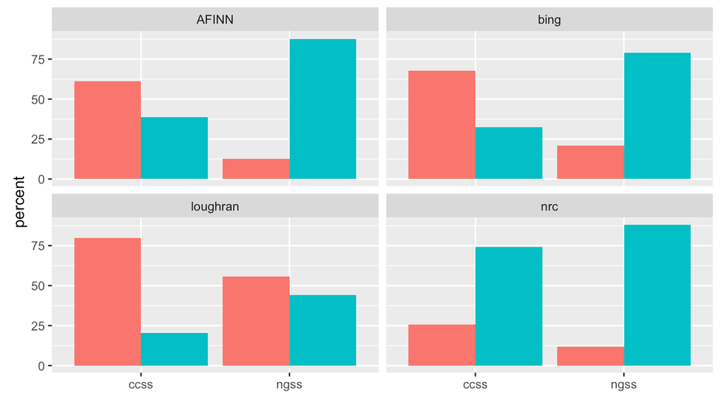

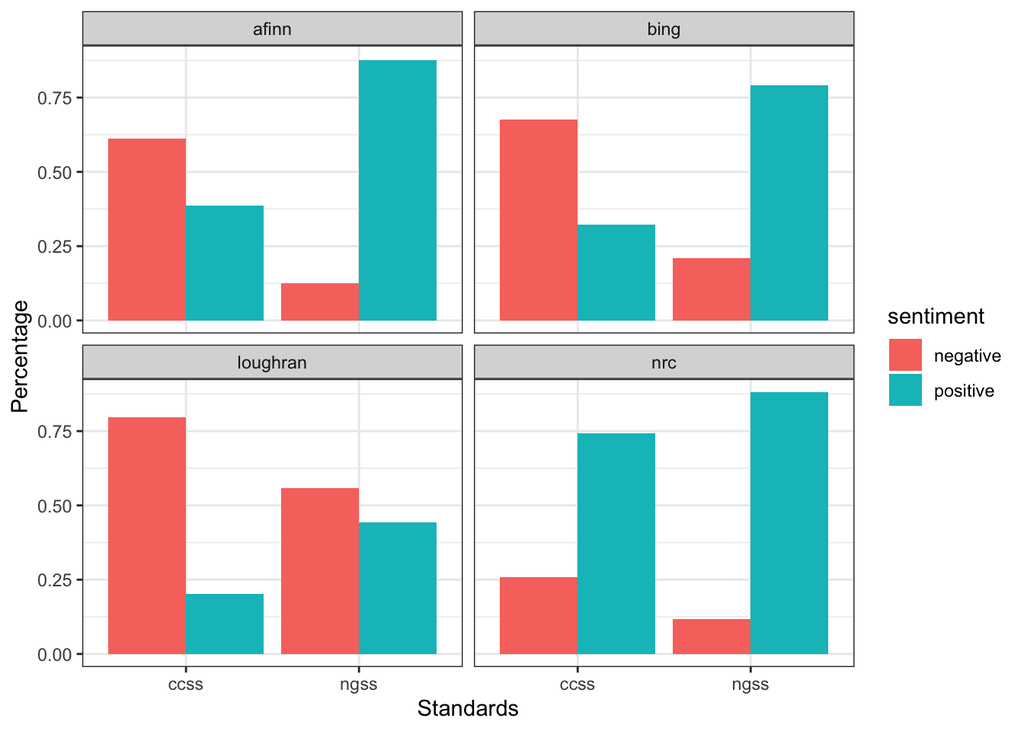

Congratulations, you’ve completed your Intro to text mining Badge! Complete the following steps to submit your work for review:

1. Change the name of the `author:` in the [YAML header](https://monashdatafluency.github.io/r-rep-res/yaml-header.html) at the very top of this document to your name. As noted in [Reproducible Research in R](https://monashdatafluency.github.io/r-rep-res/index.html), The YAML header controls the style and feel for knitted document but doesn’t actually display in the final output.
2. Click the yarn icon above to “knit” your data product to a [HTML](https://bookdown.org/yihui/rmarkdown/html-document.html) file that will be saved in your R Project folder.
3. Commit your changes in GitHub Desktop and push them to your online GitHub repository.
4. Publish your HTML page the web using one of the following [publishing methods](https://rpubs.com/cathydatascience/518692):
   - Publish on [RPubs](https://rpubs.com) by clicking the “Publish” button located in the Viewer Pane when you knit your document. Note, you will need to quickly create a RPubs account.
   - Publishing on GitHub using either [GitHub Pages](https://pages.github.com) or the [HTML previewer](http://htmlpreview.github.io).
5. Post a new discussion on GitHub to our [Text mining Badges forum](https://github.com/orgs/laser-institute/teams/network-analysis/discussions/3). In your post, include a link to your published web page and a short reflection highlighting one thing you learned from this lab and one thing you’d like to explore further.